### This program allows rapid assessment of a variety of machine learning algorithms to evaluate a

- Classification model in which a binary outcome (0/1, TRUE/FALSE, toxic/non-toxic) is being predicted
- Regression model in which a number is being predicted

#### This is a R Markdown program.

#### RStudio is recommended to run the program, either in chunks or all at once. To run all chunks automatically, use the Knit option in RStudio.

#### With the exception of what you are trying to predict, all data must be an integer or numeric data type. Factor variables in the dataset are automatically deleted. The next iteration of this program will allow additional factor variables.

Date: 14 November 2018 Author: Neal Cariello  
Senior Toxicologist  
Integrated Laboratory Systems, Research Triangle Park, NC

Supporting:  
NTP Interagency Center for the Evaluation of Alternative Toxicological Methods (NICEATM)  
https://www.niehs.nih.gov/research/atniehs/dntp/assoc/niceatm/index.cfm

email: cariello@niehs.nih.gov, ncariello@ils-inc.com, neal.f.cariello@gmail.com

Multiple machine learning algorithms can be used to easily evaluate different models sequentially using the syntax:  
MLmethods <- c(‘rf’, ‘svmRadial’, ‘xgbLinear’, etc)

R Markdown is used so all code and output is in a single HTML file.

The workflow uses the R package caret which greatly simplifies coding and presents a unified interface for 238 machine learning algorithms. The caret package varies tuning parameters when appropriate for a given machine learning method.

The main caret page is at http://topepo.github.io/caret/index.html

The default is to scale the data to mean 0 and standard deviation 1. This is also called a Z-Score transformation. Scaling is done in the function ModelFit(). Different data transformations are available.

My recommendation is to:

- Scale the input data assuming the variables have different ranges.
  - Not doing so will favor the variables with the highest values. For example, the house price will greatly influence the model since it has a much higher range than the number of bedrooms:
    - House price in thousands (range 100 - 1000)
    - Number of bedrooms (range 1 - 6)
  - A variable with an arbitrary scale should always be normalized
    - For example, the house price can be expressed as thousands of dollars or dollars (1,000 vs 1,000,000).

Analyzing data with missing values can be problematical and the default is to:

- Remove all rows with >10% missing values THEN
- Remove all columns with >10% missing values
- Impute missing values using the k-Nearest Neighbor method in the DMwR package
- The percent missing values can set set by the user

The program defaults to:

- Remove highly-correlated variables
  - It is important to removed highly-correlated variables since they may be reporting on the same features and not removing them may lead to over-optimistic performance metrics.
- Remove variables with near-zero variance
  - Features with near-zero variance contribute little to the model and will increase compute time

See the accompaning Word document for more program information,

This is a R Markdown program. Individual chunks can be executed or the entire program can be  
run using the Knit option in RStudio.

This code was run on Windows 7 and 10 using R 3.5.1

## User defined variables and conditions to run program

```
## [1] "Windows configuation"
```

```
## Path to store the R environment is:
##  C:/Google Drive/R/caret/Generic Caret Workflow/00_release/niceatm-machine-learning-pipeline/for_fitted_models/
```

## Functions

```
## [1] "Using classification model"
```

## Load Data, Inspect Distribution, Check For NA’s And Perform Optional Imputation

[output not shown]

```
## [1] "This program requires that all data other than ***toPredict*** be numeric.  Removing factor columns: "
## [1] "extra_factor_variable"
```

```
## [1] "Dataframe dimensions after imputation:"
```

```
## [1] 2019   59
```

```
## [1] "Variable names:"
```

```
##  [1] "toPredict"               "AngleCh1"
##  [3] "AreaCh1"                 "AvgIntenCh1"
##  [5] "AvgIntenCh2"             "AvgIntenCh3"
##  [7] "AvgIntenCh4"             "ConvexHullAreaRatioCh1"
##  [9] "ConvexHullPerimRatioCh1" "DiffIntenDensityCh1"
## [11] "DiffIntenDensityCh3"     "DiffIntenDensityCh4"
## [13] "EntropyIntenCh1"         "EntropyIntenCh3"
## [15] "EntropyIntenCh4"         "EqCircDiamCh1"
## [17] "EqEllipseLWRCh1"         "EqEllipseOblateVolCh1"
## [19] "EqEllipseProlateVolCh1"  "EqSphereAreaCh1"
## [21] "EqSphereVolCh1"          "FiberAlign2Ch3"
## [23] "FiberAlign2Ch4"          "FiberLengthCh1"
## [25] "FiberWidthCh1"           "IntenCoocASMCh3"
## [27] "IntenCoocASMCh4"         "IntenCoocContrastCh3"
## [29] "IntenCoocContrastCh4"    "IntenCoocEntropyCh3"
## [31] "IntenCoocEntropyCh4"     "IntenCoocMaxCh3"
## [33] "IntenCoocMaxCh4"         "KurtIntenCh1"
## [35] "KurtIntenCh3"            "KurtIntenCh4"
## [37] "LengthCh1"               "NeighborAvgDistCh1"
## [39] "NeighborMinDistCh1"      "NeighborVarDistCh1"
## [41] "PerimCh1"                "ShapeBFRCh1"
## [43] "ShapeLWRCh1"             "ShapeP2ACh1"
## [45] "SkewIntenCh1"            "SkewIntenCh3"
## [47] "SkewIntenCh4"            "SpotFiberCountCh3"
## [49] "SpotFiberCountCh4"       "TotalIntenCh1"
## [51] "TotalIntenCh2"           "TotalIntenCh3"
## [53] "TotalIntenCh4"           "VarIntenCh1"
## [55] "VarIntenCh3"             "VarIntenCh4"
## [57] "WidthCh1"                "XCentroid"
## [59] "YCentroid"
```

```
## [1] "There should be one factor variable with two levels.  All other data should be integer or numeric"
```

```
## [1] "Data types"
```

```
##
##  factor integer numeric
##       1       7      51
```

```
## [1] "Dataframe structure:"
```

```
## 'data.frame':    2019 obs. of  59 variables:
##  $ toPredict              : Factor w/ 2 levels "PS","WS": 1 1 2 1 1 2 2 1 2 2 ...
##  $ AngleCh1               : num  143.25 133.75 106.65 69.15 2.89 ...
##  $ AreaCh1                : int  185 819 431 298 285 172 177 251 495 384 ...
##  $ AvgIntenCh1            : num  15.7 31.9 28 19.5 24.3 ...
##  $ AvgIntenCh2            : num  4.95 206.88 116.32 102.29 112.42 ...
##  $ AvgIntenCh3            : num  9.55 69.92 63.94 28.22 20.47 ...
##  $ AvgIntenCh4            : num  2.21 164.15 106.7 31.03 40.58 ...
##  $ ConvexHullAreaRatioCh1 : num  1.12 1.26 1.05 1.2 1.11 ...
##  $ ConvexHullPerimRatioCh1: num  0.92 0.797 0.935 0.866 0.957 ...
##  $ DiffIntenDensityCh1    : num  29.5 31.9 32.5 26.7 31.6 ...
##  $ DiffIntenDensityCh3    : num  13.8 43.1 36 22.9 21.7 ...
##  $ DiffIntenDensityCh4    : num  6.83 79.31 51.36 26.39 25.03 ...
##  $ EntropyIntenCh1        : num  4.97 6.09 5.88 5.42 5.66 ...
##  $ EntropyIntenCh3        : num  4.37 6.64 6.68 5.44 5.29 ...
```

[output cut: 45 more lines]

```
##  toPredict    AngleCh1            AreaCh1        AvgIntenCh1
##  PS:1300   Min.   :  0.03088   Min.   : 150.0   Min.   :  15.16
##  WS: 719   1st Qu.: 53.89221   1st Qu.: 193.0   1st Qu.:  35.36
##            Median : 90.58877   Median : 253.0   Median :  62.34
##            Mean   : 90.49340   Mean   : 320.3   Mean   : 126.07
##            3rd Qu.:126.68201   3rd Qu.: 362.5   3rd Qu.: 143.19
##            Max.   :179.93932   Max.   :2186.0   Max.   :1418.63
##   AvgIntenCh2     AvgIntenCh3       AvgIntenCh4
##  Min.   :  1.0   Min.   :   0.12   Min.   :  0.5633
##  1st Qu.: 45.0   1st Qu.:  33.50   1st Qu.: 40.6797
##  Median :173.5   Median :  67.43   Median : 90.2500
##  Mean   :189.1   Mean   :  96.42   Mean   :140.7016
##  3rd Qu.:279.3   3rd Qu.: 127.34   3rd Qu.:191.1704
##  Max.   :989.5   Max.   :1205.51   Max.   :886.8375
##  ConvexHullAreaRatioCh1 ConvexHullPerimRatioCh1 DiffIntenDensityCh1
##  Min.   :1.006          Min.   :0.5106          Min.   : 25.76
##  1st Qu.:1.065          1st Qu.:0.8570          1st Qu.: 43.53
##  Median :1.149          Median :0.9133          Median : 55.81
##  Mean   :1.206          Mean   :0.8958          Mean   : 72.66
##  3rd Qu.:1.281          3rd Qu.:0.9556          3rd Qu.: 79.91
##  Max.   :2.900          Max.   :0.9965          Max.   :442.77
##  DiffIntenDensityCh3 DiffIntenDensityCh4 EntropyIntenCh1 EntropyIntenCh3
##  Min.   :  1.414     Min.   :  2.307     Min.   :4.708   Min.   :0.2167
##  1st Qu.: 29.026     1st Qu.: 31.679     1st Qu.:6.029   1st Qu.:4.6120
##  Median : 54.141     Median : 60.090     Median :6.572   Median :5.8492
##  Mean   : 74.328     Mean   : 87.183     Mean   :6.578   Mean   :5.4820
##  3rd Qu.: 96.858     3rd Qu.:115.064     3rd Qu.:7.038   3rd Qu.:6.6059
##  Max.   :470.690     Max.   :531.347     Max.   :9.476   Max.   :8.0128
##  EntropyIntenCh4  EqCircDiamCh1   EqEllipseLWRCh1  EqEllipseOblateVolCh1
##  Min.   :0.3734   Min.   :13.86   Min.   : 1.009   Min.   :  146.5
##  1st Qu.:4.6667   1st Qu.:15.71   1st Qu.: 1.415   1st Qu.:  277.6
##  Median :5.8039   Median :17.97   Median : 1.825   Median :  433.3
##  Mean   :5.5067   Mean   :19.48   Mean   : 2.108   Mean   :  714.7
##  3rd Qu.:6.6638   3rd Qu.:21.50   3rd Qu.: 2.450   3rd Qu.:  785.1
##  Max.   :8.2733   Max.   :52.76   Max.   :11.312   Max.   :11689.0
##  EqEllipseProlateVolCh1 EqSphereAreaCh1  EqSphereVolCh1  FiberAlign2Ch3
##  Min.   :  63.85        Min.   : 603.8   Min.   : 1395   Min.   :1.000
##  1st Qu.: 148.36        1st Qu.: 775.7   1st Qu.: 2031   1st Qu.:1.290
##  Median : 224.36        Median :1014.6   Median : 3039   Median :1.469
##  Mean   : 361.57        Mean   :1283.4   Mean   : 4918   Mean   :1.454
```

[output cut: 57 more lines]

```
##  Max.   :50.000    Max.   :741411   Max.   :363311   Max.   :313433
##  TotalIntenCh4     VarIntenCh1      VarIntenCh3        VarIntenCh4
##  Min.   :    96   Min.   : 11.47   Min.   :  0.8693   Min.   :  2.301
##  1st Qu.:  9939   1st Qu.: 25.30   1st Qu.: 36.7047   1st Qu.: 47.427
##  Median : 24839   Median : 42.50   Median : 69.1166   Median : 87.251
##  Mean   : 40551   Mean   : 72.20   Mean   : 98.5549   Mean   :120.021
##  3rd Qu.: 55004   3rd Qu.: 81.77   3rd Qu.:123.8391   3rd Qu.:159.137
##  Max.   :519602   Max.   :642.02   Max.   :757.0210   Max.   :933.524
##     WidthCh1        XCentroid       YCentroid
##  Min.   : 6.393   Min.   :  9.0   Min.   :  8.0
##  1st Qu.:13.820   1st Qu.:142.0   1st Qu.: 88.0
##  Median :16.188   Median :262.0   Median :165.0
##  Mean   :17.624   Mean   :260.7   Mean   :177.3
##  3rd Qu.:19.784   3rd Qu.:382.0   3rd Qu.:253.0
##  Max.   :54.745   Max.   :501.0   Max.   :501.0
```

```
##   toPredict variable      value
## 1        PS AngleCh1 143.247705
## 2        PS AngleCh1 133.752037
## 3        WS AngleCh1 106.646387
## 4        PS AngleCh1  69.150325
## 5        PS AngleCh1   2.887837
## 6        WS AngleCh1  40.748298
```

```
## Variable plots may be unreadable in the HTML output, the recommendation is to enlarge the R plot window
##     and take a screen shot of this.
```

[figure not shown]

```
## [1] "Number of workers: 3"
## [1] "Returns TRUE if doPar backend is registed: TRUE"
## [1] "Name : doParallelSNOW"
## [1] "Version: 1.0.11"
## [1] "Cores: 4"
## Totalram:  31.910 GiB
## Freeram:   21.920 GiB
## [1] "Parallel processing enabled"
```

## Determine features for possible exclusion: near zero variance

```
## [1] "Variables with near zero variance will be removed"
## [1] There are no columns with near zero variance
```

## Highly Correlated Variables (Also Called Features) For Possible Exclusion

```
## The plot may be unreadable in the HTML output, the recommendation is to enlarge the R plot window
##     and take a screen shot of this.
```

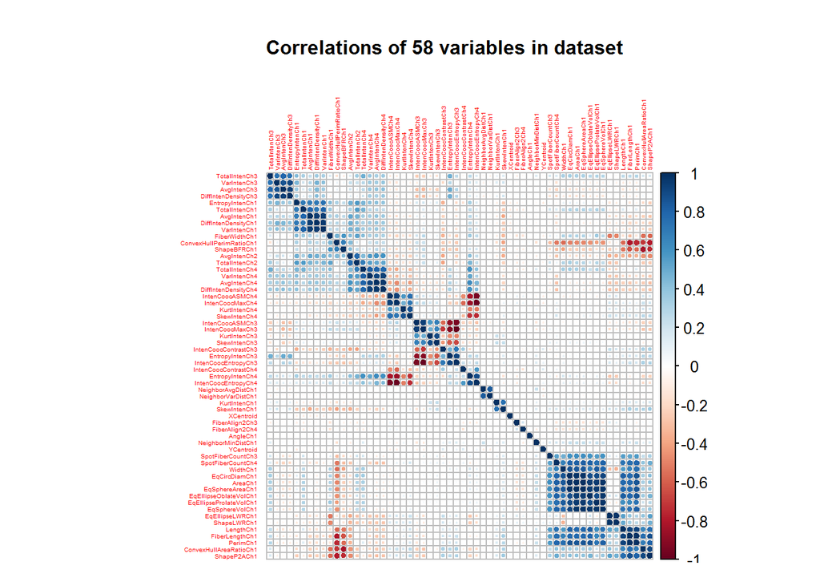

```
##  [1] "Highly correlated variables being deleted: EqCircDiamCh1"
##  [2] "Highly correlated variables being deleted: EqSphereAreaCh1"
##  [3] "Highly correlated variables being deleted: EqSphereVolCh1"
##  [4] "Highly correlated variables being deleted: AvgIntenCh4"
##  [5] "Highly correlated variables being deleted: AreaCh1"
##  [6] "Highly correlated variables being deleted: EqEllipseOblateVolCh1"
##  [7] "Highly correlated variables being deleted: IntenCoocEntropyCh3"
##  [8] "Highly correlated variables being deleted: IntenCoocEntropyCh4"
##  [9] "Highly correlated variables being deleted: FiberLengthCh1"
## [10] "Highly correlated variables being deleted: EqEllipseLWRCh1"
## [11] "Highly correlated variables being deleted: DiffIntenDensityCh1"
## [1] "Removed 11 highly correlated columns"
```

### PCA and t-SNE data visualization performed only for classification model

```
## [1] "Data visualization with T-SNE and PCA will be performed"
```

```
## [1] "Data has been scaled to mean 0 and standard deviation 1 (also known as Z-scaling for data visualization)"
## Read the 2019 x 47 data matrix successfully!
## Using no_dims = 2, perplexity = 100.000000, and theta = 0.500000
## Computing input similarities...
## Normalizing input...
## Building tree...
##  - point 0 of 2019
## Done in 1.24 seconds (sparsity = 0.218312)!
## Learning embedding...
## Iteration 50: error is 63.141408 (50 iterations in 0.69 seconds)
## Iteration 100: error is 63.141408 (50 iterations in 0.69 seconds)
## Iteration 150: error is 63.141408 (50 iterations in 0.72 seconds)
## Iteration 200: error is 63.141408 (50 iterations in 0.75 seconds)
## Iteration 250: error is 63.141408 (50 iterations in 0.81 seconds)
## Iteration 300: error is 1.738379 (50 iterations in 0.72 seconds)
## Iteration 350: error is 1.353585 (50 iterations in 0.61 seconds)
## Iteration 400: error is 1.316631 (50 iterations in 0.60 seconds)
## Iteration 450: error is 1.301763 (50 iterations in 0.60 seconds)
## Iteration 500: error is 1.295625 (50 iterations in 0.62 seconds)
## Fitting performed in 6.82 seconds.
```

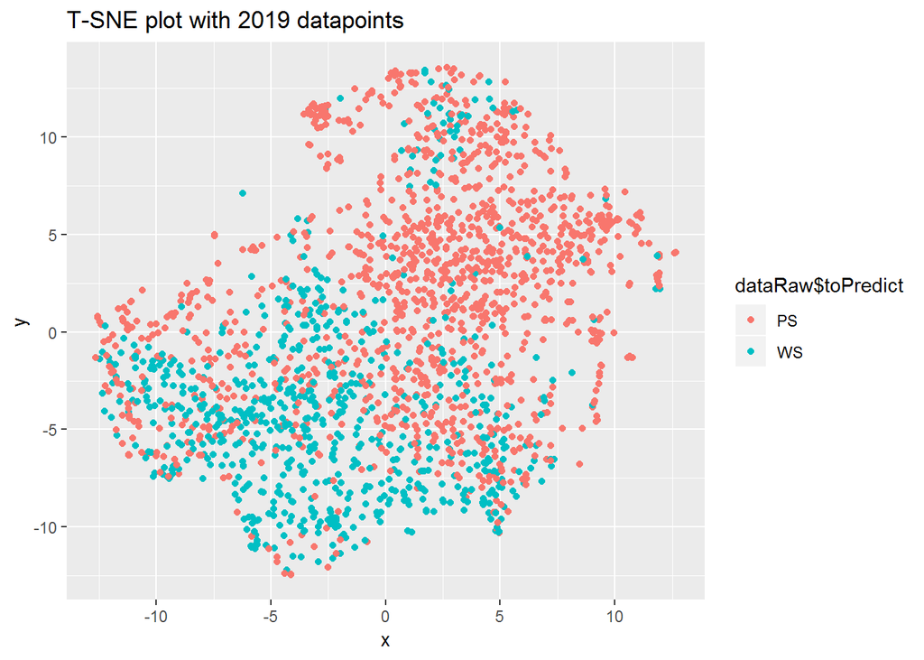

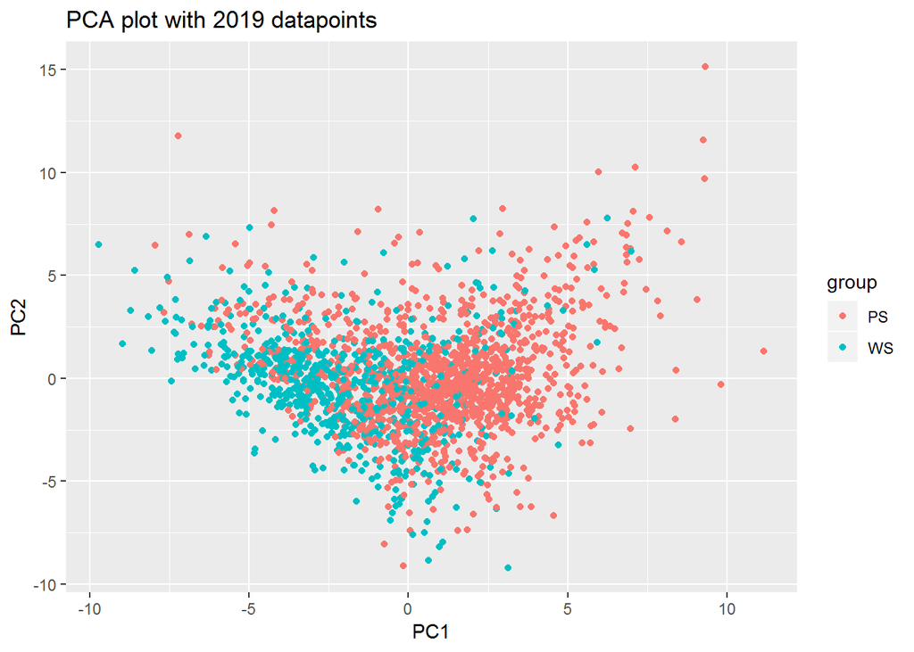

## Create training and test datasets. Check class imbalance.

### caret has some simple methods for correcting class imbalance, see caret::downSample and caret:: upSample

```
## [1] 1515   48
```

```
## [1] 504  48
```

```
## [1] Overall imbalance in Class variable that we are trying to predict.
##
##   PS   WS
## 1300  719
## [1] "Ratio of class imbalance for entire dataset is 1.81 to 1"
## [1] "Class imbalance in training dataset"
##
##  PS  WS
## 975 540
## [1] "Ratio of class imbalance for training dataset 1.81 to 1"
## [1] "Class imbalance in testing dataset"
##
##  PS  WS
## 325 179
## [1] "Ratio of class imbalance for testing dataset is 1.82 to 1"
```

## Print runtime options, Run Models and Save R Environment To Disk

See Max Kuhn’s caret website about picking models that are very different from one another (orthogonal).  
http://topepo.github.io/caret/models-clustered-by-tag-similarity.html

```
## [1] "Final data dimensions"
```

```
## [1] 2019   48
```

```
## [1] "USER SETTINGS ARE:"
```

```
## Date:  2018_11_14
```

```
## Model type:  CLASSIFICATION
```

```
## Machine Learning Methods:  rf knn svmRadial
```

```
## Parallel computing:  TRUE
```

```
## Remove highly-correlated variables:  TRUE
```

```
## Remove low variance variable:  TRUE
```

```
## Use default datasets for testing program:  TRUE
```

```
## Visualization for categorical data:  TRUE
```

```
## Add NAs:  FALSE
```

```
## [1] "ML methods used: rf"        "ML methods used: knn"
## [3] "ML methods used: svmRadial"
```

```
## [1] Starting rf at 2018-11-14 15:56:26
## [1] "Time to run rf"
## Time difference of 2.136006 mins
## [1] rfFit created
## [1] "-------------------------------------------"
## [1] Starting knn at 2018-11-14 15:58:34
## [1] "Time to run knn"
## Time difference of 3.039537 secs
## [1] knnFit created
## [1] "-------------------------------------------"
## [1] Starting svmRadial at 2018-11-14 15:58:37
## [1] "Time to run svmRadial"
## Time difference of 27.27524 secs
## [1] svmRadialFit created
## [1] "-------------------------------------------"
```

```
## [1] "Overall time to run models 3 models:"
```

```
## Time difference of 2.641513 mins
```

## Variable Importance And Tuning Parameters

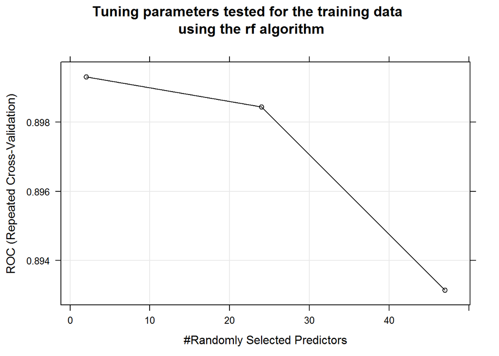

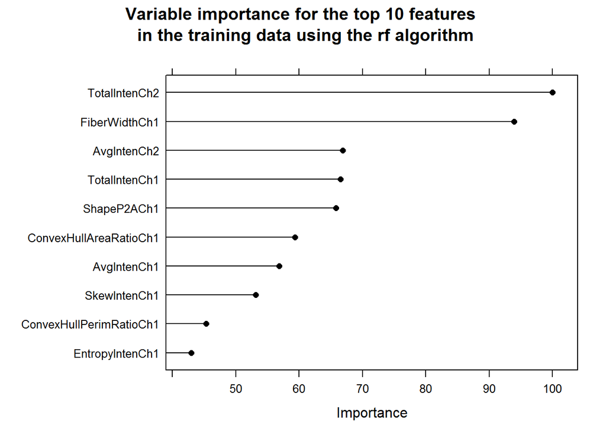

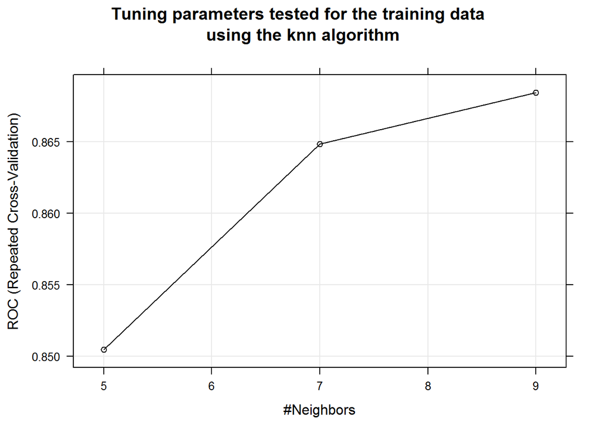

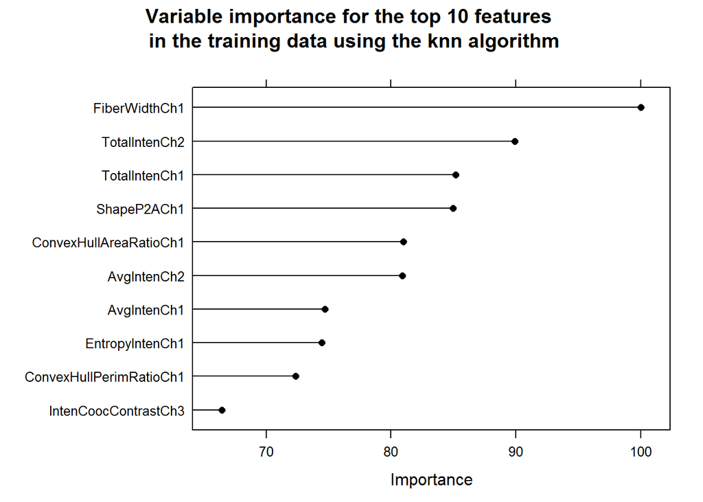

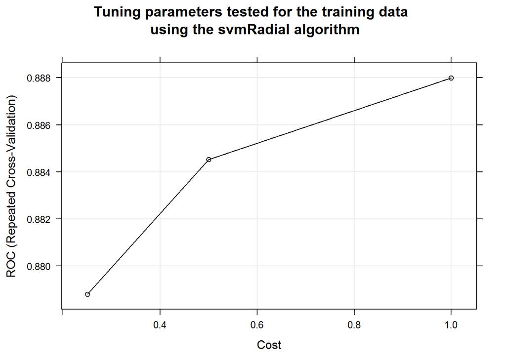

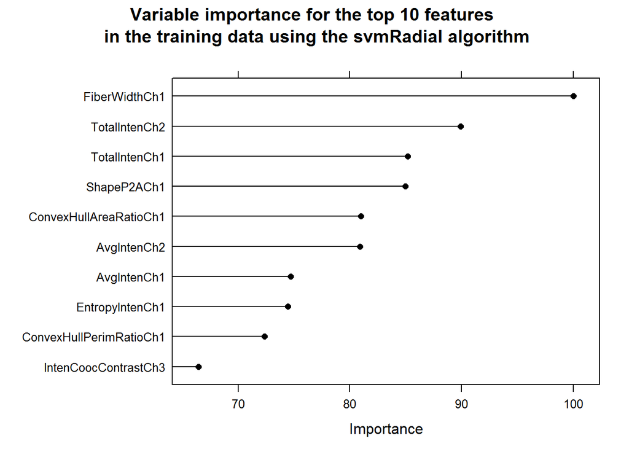

**For the CLASSIFICATION MODEL, the Receiver Operating Characteristic (ROC), Sensitivity (Sens) and Specificity (Spec) for the TRAINING data are plotted here.**

**For the REGRESSION MODEL, Mean Average Error (MAE), Root Mean Squared Error (RMSE) and Pearson R-Squared for the TRAINING data are plotted here.**

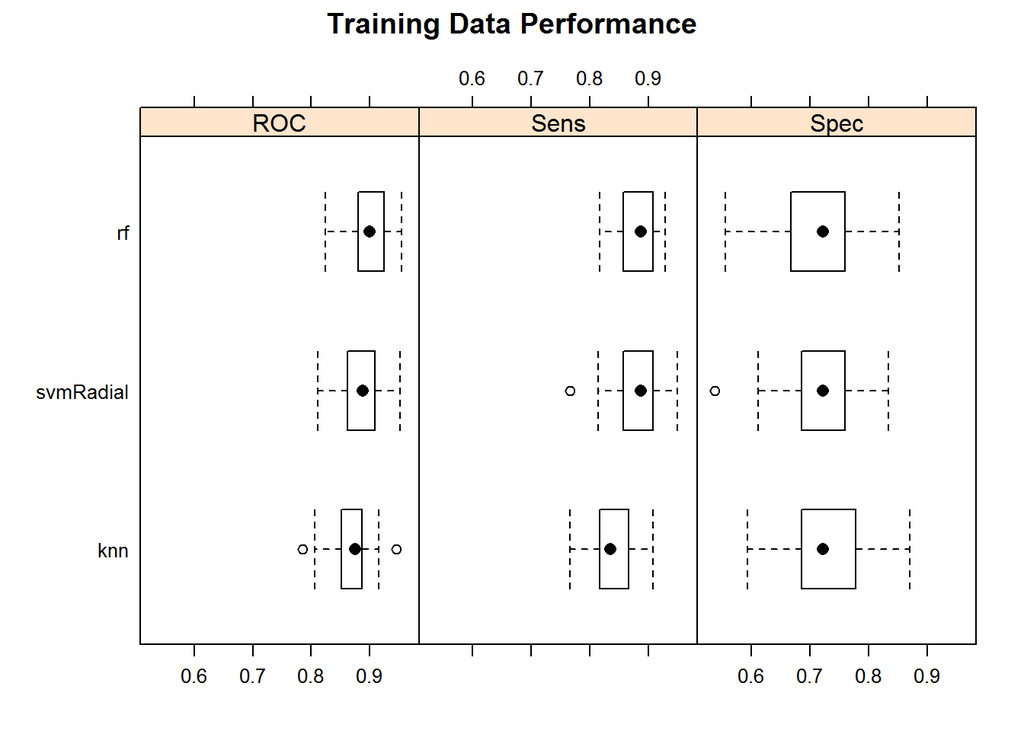

```
##
## Call:
## summary.diff.resamples(object = diffsModels)
##
## p-value adjustment: bonferroni
## Upper diagonal: estimates of the difference
## Lower diagonal: p-value for H0: difference = 0
##
## ROC
##           rf        knn      svmRadial
## rf                   0.03087  0.01132
## knn       1.274e-05          -0.01955
## svmRadial 0.301409  0.005487
##
## Sens
##           rf        knn       svmRadial
## rf                   0.042325  0.001656
## knn       9.215e-08           -0.040669
## svmRadial 1         2.729e-08
##
## Spec
##           rf     knn       svmRadial
## rf               -0.013704  0.004815
## knn       0.9248            0.018519
## svmRadial 1.0000 0.4377
```

**Performance on TESTING DATA for Classification model: Confusion Matrix, Sensitivity, Specificity, Accuracy, Kappa Statistic and more are given here.**

**Performance on TESTING DATA for Regression model: Mean Average Error (MAE), Root Mean Squared Error (RMSE) and R-Squared are given here.**

```
## [1] --------------------------   rf   ---------------------------------
## [1] Machine Learning Method: rf
## Confusion Matrix and Statistics
##
##           Reference
## Prediction  PS  WS
##         PS 292  54
##         WS  33 125
##
##                Accuracy : 0.8274
##                  95% CI : (0.7915, 0.8594)
##     No Information Rate : 0.6448
##     P-Value [Acc > NIR] : < 2e-16
##
##                   Kappa : 0.6129
##  Mcnemar's Test P-Value : 0.03201
##
##             Sensitivity : 0.8985
##             Specificity : 0.6983
##          Pos Pred Value : 0.8439
##          Neg Pred Value : 0.7911
##              Prevalence : 0.6448
##          Detection Rate : 0.5794
##    Detection Prevalence : 0.6865
##       Balanced Accuracy : 0.7984
##
##        'Positive' Class : PS
##
## [1] =====  SUMMARY: rf   =====
##       Accuracy          Kappa  AccuracyLower  AccuracyUpper   AccuracyNull
##   8.273810e-01   6.129374e-01   7.915003e-01   8.593655e-01   6.448413e-01
## AccuracyPValue  McnemarPValue
##   9.874561e-20   3.201486e-02
## [1] --------------------------   knn   ---------------------------------
## [1] Machine Learning Method: knn
## Confusion Matrix and Statistics
##
##           Reference
## Prediction  PS  WS
##         PS 273  44
```

[output cut: 44 more lines]

```
##             Specificity : 0.7095
##          Pos Pred Value : 0.8493
##          Neg Pred Value : 0.7987
##              Prevalence : 0.6448
##          Detection Rate : 0.5813
##    Detection Prevalence : 0.6845
##       Balanced Accuracy : 0.8055
##
##        'Positive' Class : PS
##
## [1] =====  SUMMARY: svmRadial   =====
##       Accuracy          Kappa  AccuracyLower  AccuracyUpper   AccuracyNull
##   8.333333e-01   6.267654e-01   7.978709e-01   8.648267e-01   6.448413e-01
## AccuracyPValue  McnemarPValue
##   4.987025e-21   3.816577e-02
```

## Stop Parallel Processing And Return To Single Thread Processing

```
## [1] "Single thread processing re-enabled"
```

```
## [1] "Time to run entire program"
```

```
## Time difference of 3.071179 mins
```